# 3_card_formatting_and_style

DG

2023-02-20

CHARACTERISTICS OF CARDS

Load relevant files

```r
#infoRDS("rev2.RDS")
crd <- tibble( readRDS(file =paste0(getwd(),"/crd2.RDS")) ) #because for some reason running readRDS when knitting outputs broken stuff
rev <- tibble( readRDS(file =paste0(getwd(),"/rev2.RDS")) )
#new_vocab <- readRDS(file =paste0(getwd(),"/new_vocabulary.RDS"))

#load('Step_2_after.RData')
check_all_decks_in_dtm <- length(unique(crd$dek.nam))
if(!all(as.numeric(rev$cid) %in% as.numeric(crd$cid))){
  (print(getwd()))
  print(summary(crd))
  print(summary(rev))
}
#print("go")
```

functions useful for looking at data TODO DELETE

```r
see.extreme.cards <- function(what.to.see,number.to.print=2,how.to.select,truncate.string.at=9999){
  newnew <- what.to.see[order(-how.to.select)]
  newnew <- newnew[1:number.to.print]
  newnew <- str_sub(newnew,end=truncate.string.at+1)  #truncate.string.at<-30
  return(newnew)
}

see.tops <- function(selector,num.to.print=3,truncate.string=999,
                     show.opposite.end=T, print.dirty=T, print.clean=T, print.deck=T, print.statistic=T){

if(print.clean) print(see.extreme.cards(what.to.see=crd$card.txt,how.to.select = selector,
                                  num.to.print,truncate.string))
if(print.dirty) print(see.extreme.cards(what.to.see=crd$card.txt.old,how.to.select = selector,
                                  num.to.print,truncate.string))
if(print.deck) print(see.extreme.cards(what.to.see=crd$dek.nam,how.to.select = selector,
                                  num.to.print,truncate.string))
if(print.statistic) print(see.extreme.cards(what.to.see=selector,how.to.select = selector,
                                  num.to.print,truncate.string))

if(show.opposite.end){
  print("--------------------")
if(print.clean) print(see.extreme.cards(what.to.see=crd$card.txt,how.to.select = -selector,
                                  num.to.print,truncate.string))
if(print.dirty) print(see.extreme.cards(what.to.see=crd$card.txt.old,how.to.select = -selector,
                                  num.to.print,truncate.string))
if(print.deck) print(see.extreme.cards(what.to.see=crd$dek.nam,how.to.select = -selector,
                                  num.to.print,truncate.string))
if(print.statistic) print(see.extreme.cards(what.to.see=selector,how.to.select = -selector,
                                  num.to.print,truncate.string))
}

}
```

Cleaning text function. Duplicate of what is in first step to debug it. Clean card text. TODO DELETE

```r
if(F){
require(stringr, quietly = T)
clean_strings <- function(ws,remove.digits=T){
ws <- gsub(pattern = '\037'," -- ",ws,fixed = T)
ws <- gsub(pattern = '<img src='," AN_IMAGE_HERE<  ",ws,fixed = T)
ws <- gsub(pattern = '<.+?>'," ",ws,fixed = F)
ws <- gsub(pattern = '[sound:'," SOUND_HERE[",ws,fixed = T)
ws <- gsub(pattern = '\\[.+?\\]'," ",ws,fixed = F)
ws <- gsub(pattern = '{{c'," ",ws,fixed = T)
ws <- gsub(pattern = '::',":",ws,fixed = T)
ws <- gsub(pattern = '}}'," ",ws,fixed = T)
if(remove.digits){
  ws <- gsub(pattern = '[[:digit:]][[:digit:]][[:digit:]]+'," % ",ws,fixed = F)
}
ws <- gsub(pattern = 'nbsp'," ",ws,fixed = T)
ws <- gsub(pattern = '/n'," ",ws,fixed = T)
ws <- str_squish(ws)
ws <- str_squish(ws)
#ws <- str_squish(ws)
}
#crd$card.txt <- crd$card.txt.old
#crd$card.txt <- sapply(crd$card.txt,clean_strings,remove.digits=F)


sound <- '
Select ALL columns\037\037[row,]\037\037\037    '
'
partial matching of names is allowed with ___, for example: <br>x<- list(aardvark = 1:5)<br>x$a gives back ___<br>x[["a"]] gives back___<br>x[["a", exact = FALSE]]\037[sound:quizlet-2689720066-front.mp3]\037[[ and $, 1 2 3 4 5, NULL, 1 2 3 4 5\037[sound:quizlet-2689720066-back.mp3]\037\037'


'Super assignment <<-\037\037The ancestors of an environment have an important relationshi
What does this matrix look like?<br><br>a <_ matrix(1:6, nrow = 2)\037\037[,1] [,2] [,3]<br>[1,] 1 3 5<br>[2,] 2 4 6<br>Notice the positional markers - e.g. [,1]. What do those mean?\037\037\037'
"What's wrong with this statement?<br><br># Create box_office<br>box_office <- c(new_hope + empire_strikes + return_jedi)\037\037What's wrong with this statement?<br><br># Create box_office<br>box_office <- c(new_hope, empire_strikes, return_jedi)<br><br>(Don't use "+"!)\037\037\037 "

b<-'Write a conditional statement where R prints "x is a negative number" if x is <- -3.\037\037x <- -3<br>if(x <0) {<br> print("x is a negative number")<br>}\037\037\037'

a<-"[[ subset\037\037Because [[ can return only a single item, you must use it with either a single positive integer or a single string. If you use a vector with [[, it will subset recursively, i.e. x[[c(1, 2)]] is equivalent to x[[1]][[2]]. This is a quirky feature that few know about, so I recommend avoiding it in favour of purrr::pluck()<br>While you must use [[ when working with lists, I'd also recommend using it with atomic vectors whenever you want to extract a single value. For example, instead of writing:\037\037\037"

print(clean_strings(sound))
'Trick on planar graphs: {{c1::use Delaunay to build proximity structures in O(n log n)}}\037'  #special need to split cards along {{ }} later
}
```

## writing style charactersitics native to anki or simplet to implement

#### viz cleaning cards and number of characters

Number of characters. Also cards with too few real characters.

```r
{
crd$wstyle.nchar <- nchar(crd$card.txt)
crd$wstyle.nchar.dirty <- nchar(crd$card.txt.old)

crd %>%
  arrange(wstyle.nchar.dirty) %>%
  filter(wstyle.nchar.dirty<10) %>%
  select(card.txt,card.txt.old,wstyle.nchar.dirty,dek.nam)%>%
  arrange(dek.nam)
}
```

```
## # A tibble: 36 × 4
##    card.txt           card.txt.old                    wstyle.nchar.dirty dek.nam
##    <chr>              <chr>                                        <int> <chr>
##  1 to go -- ir        "to go\u001fir"                                  8 AAA ea…
##  2 ir -- to go        "ir\u001fto go"                                  8 AAA ea…
##  3 i go -- voy        "i go\u001fvoy"                                  8 AAA ea…
##  4 i know -- sé       "i know\u001fsé"                                 9 AAA ea…
##  5 i see -- veo       "i see\u001fveo"                                 9 AAA ea…
##  6 ser -- to be       "ser\u001fto be"                                 9 AAA ea…
##  7 To go -- ir        "To go\u001fir"                                  8 AAA ea…
##  8 / -- -- / -- -- -- "/\u001f\u001f/\u001f\u001f\u0…                  7 ACwass…
##  9 / -- -- / -- -- -- "/\u001f\u001f/\u001f\u001f\u0…                  7 ACwass…
## 10 -- -- -- -- --     "\u001f\u001f\u001f\u001f\u001…                  5 ARlang…
## # ℹ 26 more rows
```

Distribution of number of chars of cards by subject.

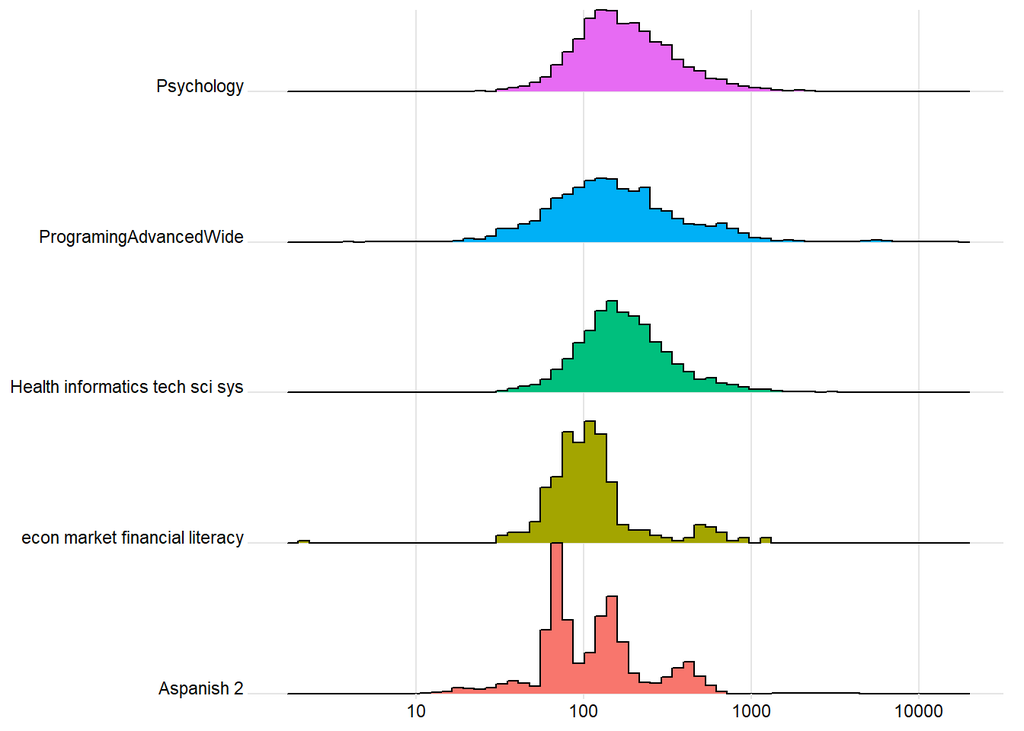

```r
if(F){
crd %>%
  arrange(wstyle.nchar) %>%
  group_by(subject) %>%
  mutate(for.cumcount=1,
    cumulative.new.notes.reviewed = cumsum(for.cumcount)) %>%
  ggplot(aes(x=cumulative.new.notes.reviewed,y=wstyle.nchar,color=subject)) + geom_point()+scale_y_log10()
}
require(ggridges)
ggplot(crd,aes(wstyle.nchar, y=subject,fill = subject, group=subject)) + geom_density_ridges(stat = "binline", bins = 60, scale = 1)+
  scale_y_discrete(expand = c(0, 0)) +
  #scale_x_continuous(expand = c(0, 0)) +
  coord_cartesian(clip = "off") +
  scale_x_log10()+
  theme_ridges(font_size = 10)+
   theme(axis.title.y = element_blank(),axis.title.x = element_blank(),legend.position  ='none')
```

Card text that becomes longer due to cleaning function because text was originaly too short or filled only one field. And ten cards shrunken most by cleaning.

```r
{
linear.correlation <- cor(log(crd$wstyle.nchar),log(crd$wstyle.nchar.dirty))
print(paste("linear correlation between log original card text and log cleaned card text",round(linear.correlation,digits=3)))

saveRDS(options(),"options_from_three.RDS")

htm <- (crd$wstyle.nchar) / crd$wstyle.nchar.dirty
crd %>%
  mutate(htm = htm) %>%
  arrange(-htm) %>%
  filter(htm > 1.6) %>%
  select(htm,dek.nam,card.txt.old,card.txt) %>%
  arrange(dek.nam)


crd %>%
  mutate(htm = htm) %>%
  arrange(htm) %>%
  slice_head(n=10) %>%
  select(htm,dek.nam,card.txt.old,card.txt) %>%
  arrange(dek.nam)
}
```

[output not shown]

```
## [1] "linear correlation between log original card text and log cleaned card text 0.9"
```

```
## # A tibble: 10 × 4
##       htm dek.nam                                 card.txt.old          card.txt
##     <dbl> <chr>                                   <chr>                 <chr>
##  1 0.0367 MathAdvanced -- Applied Statistics      "[latex]<div>\\[</di… "\\ --"
##  2 0.0367 MathAdvanced -- Applied Statistics      "[latex]<div>\\[</di… "\\ --"
##  3 0.0381 MathAdvanced -- Applied Statistics      "[latex]<div><div>\\… "\\ --"
##  4 0.0476 ProgramingAdvancedWide -- Coding        "\n<style type=\"tex… "p.p1 {…
##  5 0.0605 ProgramingAdvancedWide -- Coding        "<b></b><b>Problem: … "Proble…
##  6 0.0535 ProgramingAdvancedWide -- OO Design     "<h1 style=\"margin-… "Design…
##  7 0.0575 ProgramingAdvancedWide -- OO Design     "<div class=\"cell b… "Design…
##  8 0.0632 ProgramingAdvancedWide -- OO Design     "<h1 style=\"margin-… "Design…
##  9 0.0712 ProgramingAdvancedWide -- OO Design     "<h1 style=\"margin-… "Design…
## 10 0.0428 ProgramingAdvancedWide -- System Design "<h2 style=\"box-siz… "Commun…
```

Comparisons of number of characters before and after cleaning.

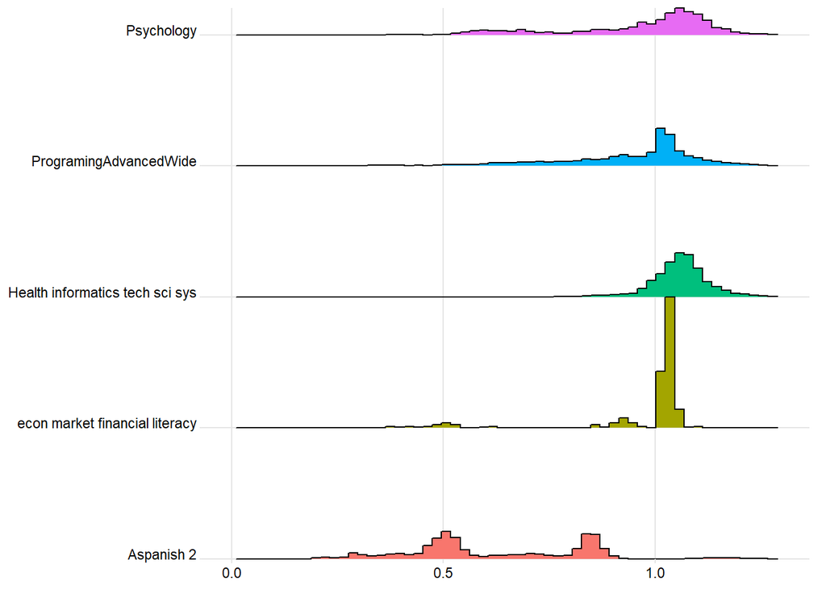

```r
require(ggridges)
ggplot(crd,aes(wstyle.nchar/wstyle.nchar.dirty, y=subject,fill = subject, group=subject)) + geom_density_ridges(stat = "binline", bins = 60, scale = 1)+
  scale_y_discrete(expand = c(0, 0)) +
  #scale_x_continuous(expand = c(0, 0)) +
  coord_cartesian(clip = "off") +
  #scale_x_log10()+) #+ ,color=subjectad
  theme_ridges(font_size = 10)+
   theme(axis.title.y = element_blank(),axis.title.x = element_blank(),legend.position  ='none') + lims(x=c(0,1.3))
```

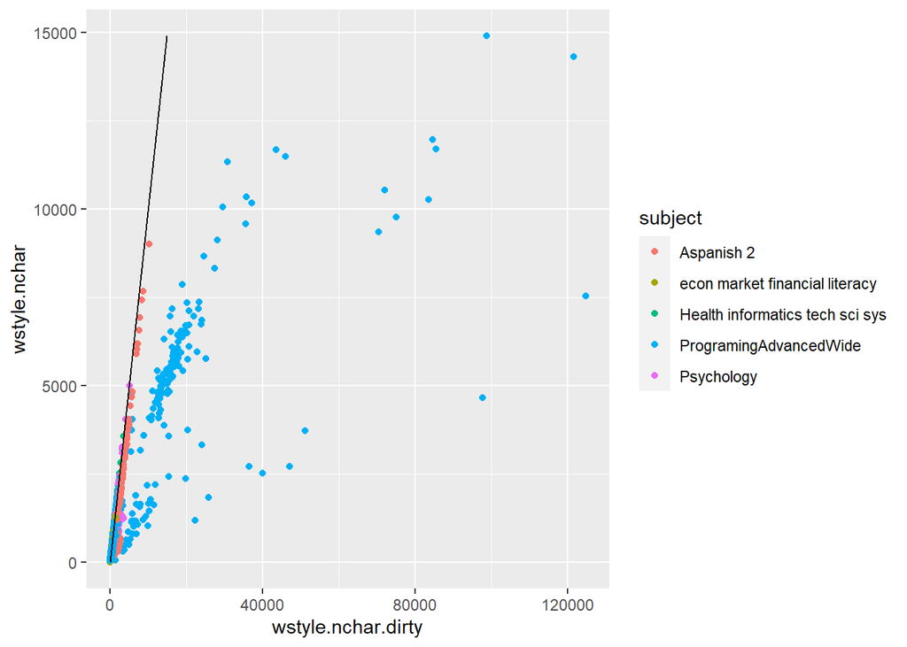

```r
linend<-min(max(crd$wstyle.nchar.dirty),max(crd$wstyle.nchar))

ggplot(crd,aes(wstyle.nchar.dirty,wstyle.nchar)) +
  geom_point(aes(color=subject)) +
  geom_segment(aes(x = 0, y = 0, xend = linend, yend = linend))#+ geom_smooth(method='lm') #+ scale_x_sqrt() + scale_y_sqrt()
```

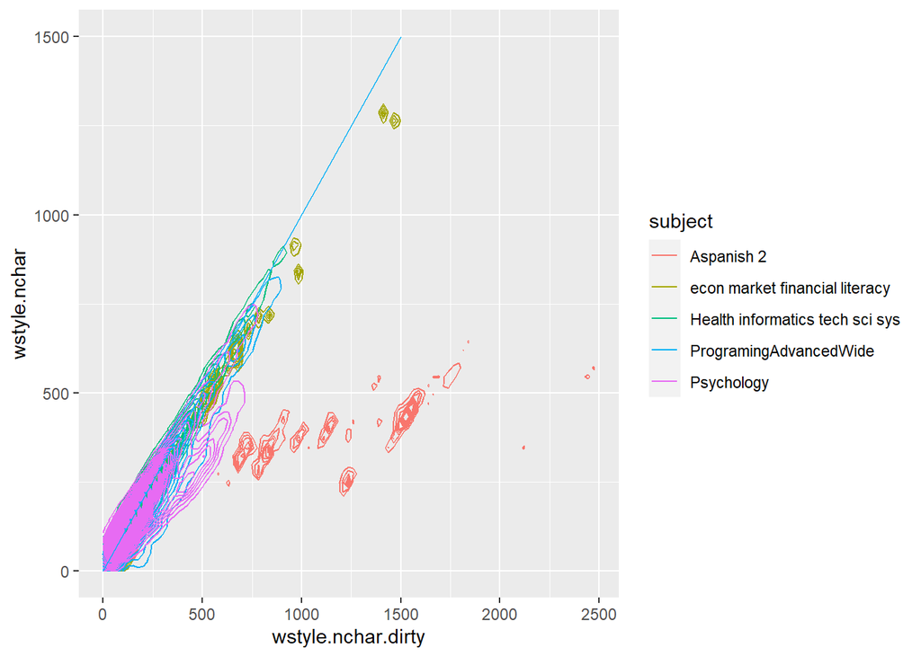

```r
if(F){
  ggplot(crd,aes(wstyle.nchar.dirty,wstyle.nchar,color=subject)) +
  geom_point(aes()) + #geom_smooth(method='lm') +
  lims(x= c(0, 2500), y = c(0, 2500))+
  geom_segment(aes(x = 0, y = 0, xend = 2500, yend = 2500))
}
crd %>%
  filter(wstyle.nchar.dirty<2500,wstyle.nchar<2500) %>%
ggplot(aes(wstyle.nchar.dirty,wstyle.nchar,color=subject))+#geom_point() +
  geom_density_2d(bins=350) +# ,color=subjectadjust=1/300
  geom_segment(aes(x = 0, y = 0, xend = 1500, yend = 1500))
```

#### splitning note into parts

Cards with only one field filled or less. Unfinished cards.

```r
require(stringr)
only.one.field <- !str_detect(crd$card.txt,'[^ -][- ]{3,500}[^ -]' )
only.one.field <- only.one.field & !str_detect(crd$card.txt.old,fixed('{{c') )
crd %>%
  mutate(only.one.field = only.one.field) %>%
  filter(only.one.field) %>%
  select(card.txt,card.txt.old,dek.nam) %>%
  arrange(dek.nam)
```

```
## # A tibble: 133 × 3
##    card.txt                                                 card.txt.old dek.nam
##    <chr>                                                    <chr>        <chr>
##  1 it is good that students generate short statements that… "it is good… AAlear…
##  2 Select the following true statements about memory accor… "Select the… AAlear…
##  3 Given a toy example in Fig. 1 induce a Naive Bayes mode… "Given a to… AAtech…
##  4 Given a toy example in Fig. 2 evaluate the performance … "Given a to… AAtech…
##  5 Given a toy example in Fig. 2 evaluate the performance … "Given a to… AAtech…
##  6 HW1. Explain the main diﬀerence between optimizing for … "HW1. Expla… AAtech…
##  7 Given a toy example in Fig. 1 induce a Decision tree mo… "Given a to… AAtech…
##  8 The goal of two-party private set intersection is to co… "The goal o… AAtech…
##  9 Alice and Bob would like to securely evaluate the logic… "Alice and … AAtech…
## 10 Variation -- -- -- -- --                                 "Variation\… ACwass…
## # ℹ 123 more rows
```

count characters in clean cue - question

```r
crd$wstyle.nchar.cue <-
  nchar(lapply(str_split(crd$card.txt,fixed("--")),function(x) x[[1]]))

crd %>%
  arrange(wstyle.nchar.cue/wstyle.nchar) %>%
  slice_head(n = 3) %>%
  select(card.txt,card.txt.old,wstyle.nchar.cue,dek.nam) %>%
  arrange(dek.nam)
```

```
## # A tibble: 3 × 4
##   card.txt                                 card.txt.old wstyle.nchar.cue dek.nam
##   <chr>                                    <chr>                   <int> <chr>
## 1 -- -- DT # Cumulative sum of column x a… "\u001f\u00…                0 ARlang…
## 2 -- -- # Print the second to last row of… "\u001f\u00…                0 ARlang…
## 3 -- -- encloses synonyms, alternative wo… "[ ]\u001f\…                0 Health…
```

```r
crd %>%
  arrange(-wstyle.nchar.cue/wstyle.nchar) %>%
  slice_head(n = 3) %>%
  select(card.txt,card.txt.old,wstyle.nchar.cue,dek.nam) %>%
  arrange(dek.nam)
```

```
## # A tibble: 3 × 4
##   card.txt                                 card.txt.old wstyle.nchar.cue dek.nam
##   <chr>                                    <chr>                   <int> <chr>
## 1 Answer TRUE or FALSE: 1.2.22 a. The red… "<div><font…             1672 MathAd…
## 2 Answer TRUE or FALSE: 1.2.22 a. The red… "<div><font…             1672 MathAd…
## 3 Answer TRUE or FALSE: 1.2.22 a. The red… "<div><font…             1672 MathAd…
```

count chars in smallest section find cards with tiny fields

```r
crd$wstyle.nchar.min.field <-
  str_split(crd$card.txt,fixed("--")) %>%
  #str_split(fixed("{{c")) %>%
  #str_split(fixed("}}")) %>%
    lapply( FUN= function(x){
                  ut<-nchar(x)
                  max(min(ut[ut>1]),0)}) %>%
  unlist()



crd$wstyle.nchar.min.field[is.infinite(crd$wstyle.nchar.min.field)] <- 0
 # summary(crd$wstyle.nchar.min.field)

cloze_min <- str_extract_all(crd$card.txt.old,pattern='\\{\\{c.+?\\}\\}') %>%
  lapply( FUN= function(x){
                  ut<-nchar(x)
                  return(max(min(ut[ut>1]),0))
                  }) %>%
  unlist()

cloze_min[is.infinite(cloze_min)] <- 0
cloze_min <- cloze_min - 8
cloze_min[cloze_min < 1] <- Inf


crd$wstyle.nchar.min.field <- pmin(crd$wstyle.nchar.min.field,cloze_min)

#bc should have split at

crd %>%
  arrange(wstyle.nchar.min.field) %>%
  slice_head(n = 5) %>%
  select(card.txt,card.txt.old,wstyle.nchar.min.field,dek.nam) %>%
  arrange(dek.nam)
```

```
## # A tibble: 5 × 4
##   card.txt                           card.txt.old wstyle.nchar.min.field dek.nam
##   <chr>                              <chr>                         <dbl> <chr>
## 1 -- -- -- -- --                     "\u001f\u00…                      0 ARlang…
## 2 MapReduce: there is/are 1:1 (how … "MapReduce:…                      1 Progra…
## 3 companies want to operate in Stag… "<div>compa…                      1 Progra…
## 4 marginal product reaches 0 at poi… "<div>margi…                      1 Progra…
## 5 --                                 "\u001f"                          0 econ m…
```

```r
crd %>%
  arrange(-wstyle.nchar.min.field) %>%
  slice_head(n = 10) %>%
  select(card.txt,card.txt.old,wstyle.nchar.min.field,dek.nam) %>%
  arrange(dek.nam) %>%
  filter(!duplicated(dek.nam))
```

```
## # A tibble: 6 × 4
##   card.txt                           card.txt.old wstyle.nchar.min.field dek.nam
##   <chr>                              <chr>                         <dbl> <chr>
## 1 "Coaching Actuaries Example 2.1.6… "Coaching A…                    639 AB sta…
## 2 "Random intercept and slope:& ; E… "Random int…                    689 MathAd…
## 3 "Let $I$ be an interval and let $… "[latex]Let…                    598 MathAd…
## 4 "p.p1 {margin: 0.0px 0.0px 0.0px … "\n\n\n\n\n…                   2440 Progra…
## 5 "Default arguments are passed to … "Default ar…                    572 basic …
## 6 "5. Which of the following are—or… "5.  Which …                    537 econ m…
```

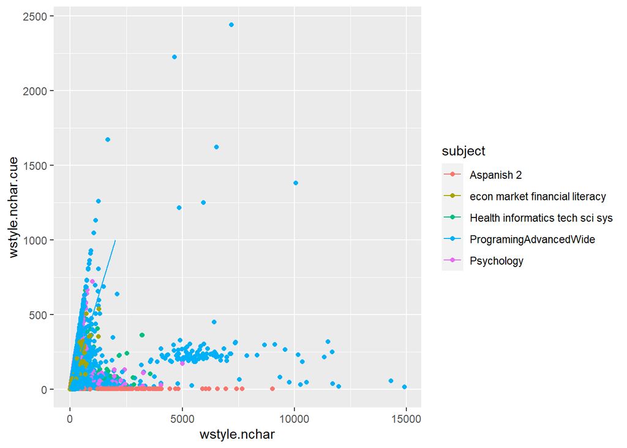

```r
ggplot(crd,aes(wstyle.nchar,wstyle.nchar.cue,color=subject)) +
  geom_point()+
  geom_segment(aes(x = 0, y = 0, xend = 2000, yend = 1000))
```

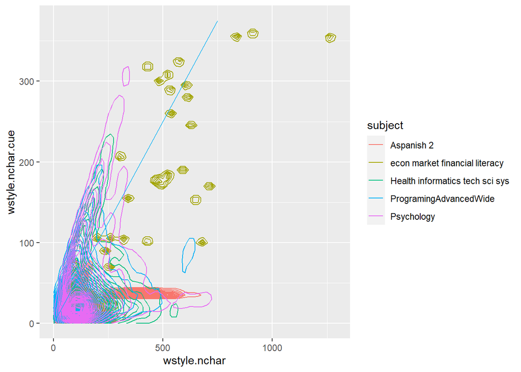

```r
crd %>%
  filter(wstyle.nchar.cue<500,wstyle.nchar<2000) %>%
ggplot(aes(wstyle.nchar,wstyle.nchar.cue,color=subject))+#geom_point() +
  geom_density_2d(bins=300)+
  geom_segment(aes(x = 0, y = 0, xend = 750, yend = 750/2))
```

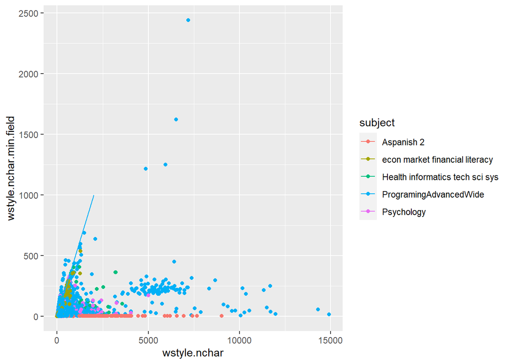

```r
ggplot(crd,aes(wstyle.nchar,wstyle.nchar.min.field,color=subject)) +
  geom_point() +
  geom_segment(aes(x = 0, y = 0, xend = 2000, yend = 1000))
```

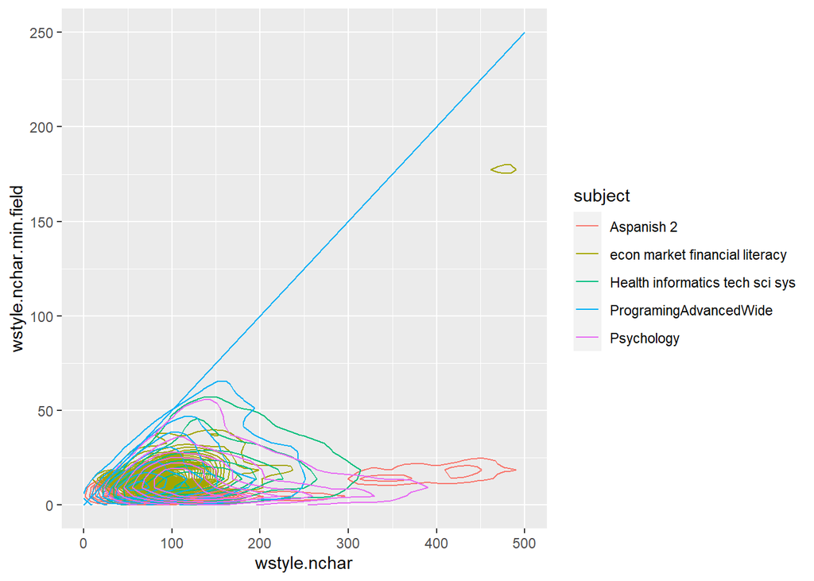

```r
crd %>%
  filter(wstyle.nchar.min.field<500,wstyle.nchar<750) %>%
ggplot(aes(wstyle.nchar,wstyle.nchar.min.field,color=subject))+#geom_point() +
  geom_density_2d(bins=200)+
  geom_segment(aes(x = 0, y = 0, xend = 500, yend = 500/2))
```

cards per note

```r
crd %>% add_count(nid) -> crd
crd$wstyle.cards.per.note <- crd$n
crd$n <- NULL

# crd %>%
#   arrange(wstyle.cards.per.note) %>%
#   slice_head(n = 3) %>%
#   select(card.txt,card.txt.old,wstyle.cards.per.note,dek.nam) %>%
#   arrange(dek.nam)
crd %>%
  group_by(card.txt) %>%
  summarise(card.txt.old=first(card.txt.old),
            wstyle.cards.per.note=first(wstyle.cards.per.note),
            dek.nam=first(dek.nam)) %>%
  slice_max(n = 3,order_by = wstyle.cards.per.note) %>%
  ungroup() %>%
  arrange(card.txt)
```

```
## # A tibble: 3 × 4
##   card.txt                            card.txt.old wstyle.cards.per.note dek.nam
##   <chr>                               <chr>                        <int> <chr>
## 1 "1:Diogenes was a 2:4th c. BC (c.4… "{{c1::Diog…                    19 Alogic…
## 2 "1:Hugo Grotius (also known as 1:H… "{{c1::Hugo…                    14 Alogic…
## 3 "1:Theophrastus was a 16:4th/3rd c… "{{c1::Theo…                    16 Alogic…
```

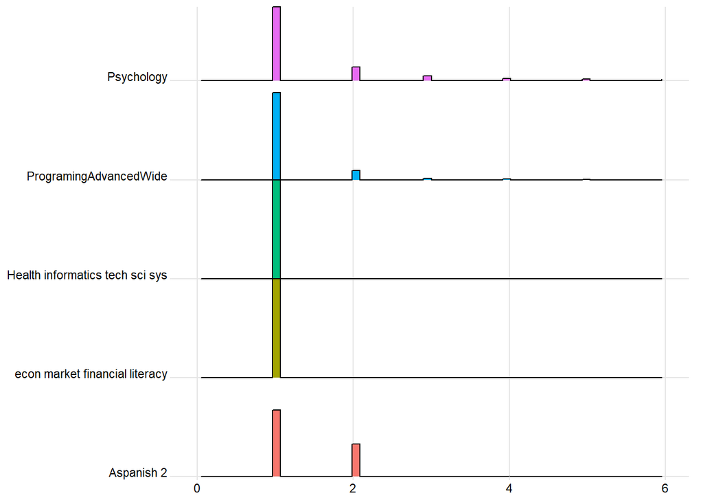

```r
crd %>%
  filter(wstyle.cards.per.note>0) %>%
ggplot(aes(wstyle.cards.per.note, y=subject,fill = subject, group=subject)) + geom_density_ridges(stat = "binline", bins = 60, scale = 1)+
  scale_y_discrete(expand = c(0, 0)) +
  #scale_x_continuous(expand = c(-.5, 0)) +
  coord_cartesian(clip = "off",expand =T) +
  #scale_x_log10()+) #+ ,color=subjectad
  theme_ridges(font_size = 10)+
   theme(axis.title.y = element_blank(),axis.title.x = element_blank(),legend.position  ='none')  +lims(x=c(0,6))
```

Count Clozes

```r
crd$wstyle.clozes <- str_count(string = crd$card.txt.old,fixed("{{c"))

crd %>%
  arrange(-wstyle.clozes ) %>%
  slice_head(n = 3) %>%
  select(card.txt,card.txt.old,wstyle.clozes,dek.nam) %>%
  arrange(dek.nam)
```

```
## # A tibble: 3 × 4
##   card.txt                                    card.txt.old wstyle.clozes dek.nam
##   <chr>                                       <chr>                <int> <chr>
## 1 1:Diogenes was a 2:4th c. BC (c.412-c.323 … "{{c1::Diog…            19 Alogic…
## 2 1:Diogenes was a 2:4th c. BC (c.412-c.323 … "{{c1::Diog…            19 Alogic…
## 3 1:Diogenes was a 2:4th c. BC (c.412-c.323 … "{{c1::Diog…            19 Alogic…
```

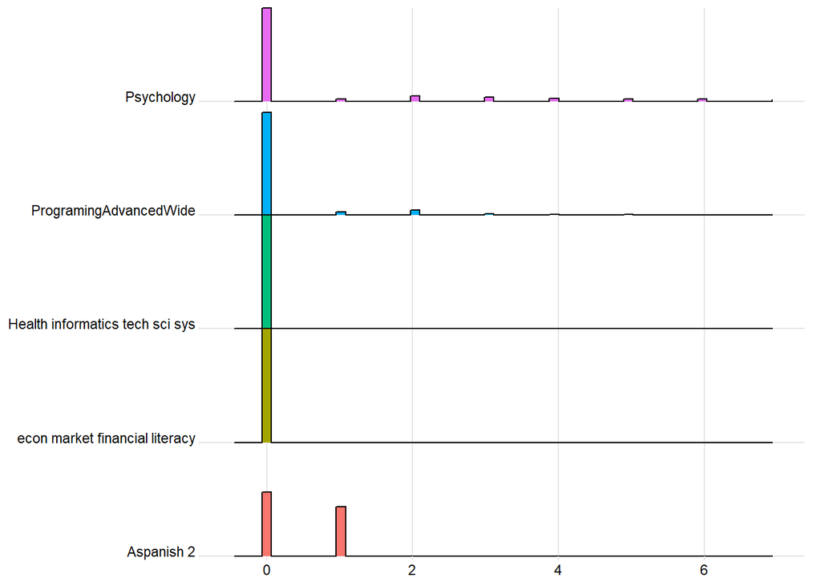

```r
ggplot(crd,aes(wstyle.clozes, y=subject,fill = subject, group=subject)) + geom_density_ridges(stat = "binline", bins = 60, scale = 1)+
  scale_y_discrete(expand = c(0, 0)) +
  #scale_x_continuous(expand = c(-.5, 0)) +
  coord_cartesian(clip = "off",expand =T) +
  #scale_x_log10()+) #+ ,color=subjectad
  theme_ridges(font_size = 10)+
   theme(axis.title.y = element_blank(),axis.title.x = element_blank(),legend.position  ='none')  +lims(x=c(-.50,7))
```

count fields per card

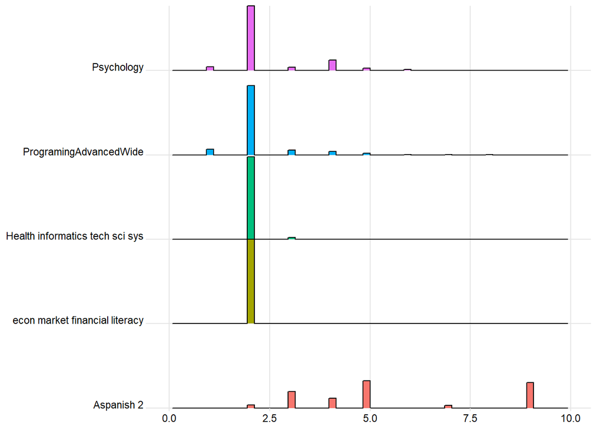

```r
crd$wstyle.n.fields <-
  str_split(crd$card.txt,fixed("--")) %>%
  #str_split(fixed("{{c")) %>%
  #str_split(fixed("}}")) %>%
    lapply( FUN= function(x){
                  ut<-nchar(x)
                  ut<-ut[ut>1]
                  return(length(ut))}) %>%
  unlist()


ggplot(crd,aes(wstyle.n.fields, y=subject,fill = subject, group=subject)) + geom_density_ridges(stat = "binline", bins = 60, scale = 1)+
  scale_y_discrete(expand = c(0, 0)) +
  #scale_x_continuous(expand = c(-.5, 0)) +
  coord_cartesian(clip = "off",expand =T) +
  #scale_x_log10()+) #+ ,color=subjectad
  theme_ridges(font_size = 10)+
   theme(axis.title.y = element_blank(),axis.title.x = element_blank(),legend.position  ='none') +lims(x=c(0,10))
```

```r
crd %>%
  #filter(wstyle.n.fields>0) %>%
  mutate(interest = wstyle.n.fields) %>%
  arrange(interest) %>%
  slice_head(n=10) %>%
  select(card.txt,card.txt.old,interest,dek.nam) %>%
  arrange(dek.nam) %>%
  filter(!duplicated(dek.nam))
```

```
## # A tibble: 4 × 4
##   card.txt                                         card.txt.old interest dek.nam
##   <chr>                                            <chr>           <int> <chr>
## 1 -- -- -- -- --                                   "\u001f\u00…        0 ARlang…
## 2 Is 1:necessary to notice when you are 2:confuse… "Is {{c1::n…        1 Alogic…
## 3 Three aspects of the 4:teaching phase in Learni… "Three aspe…        1 Alogic…
## 4 --                                               "\u001f"            0 econ m…
```

```r
crd %>%
  #filter(wstyle.n.fields>0) %>%
  mutate(interest = wstyle.n.fields) %>%
  arrange(-interest) %>%
  slice_head(n=10) %>%
  select(card.txt,card.txt.old,interest,dek.nam) %>%
  arrange(dek.nam) %>%
  filter(!duplicated(dek.nam))
```

```
## # A tibble: 1 × 4
##   card.txt                                         card.txt.old interest dek.nam
##   <chr>                                            <chr>           <int> <chr>
## 1 "364 -- (n.) número, cifra, (v.) numerar, conta… "364\u001f(…       23 Aspani…
```

cloze vs note vs fields a few have both and many require filling in a bunch of cloze prompts at once

```r
if(F){
# require(GGally)
# crd %>%
#   mutate(
#     wstyle.clozes = runif(length(wstyle.clozes),-.4,.4) + wstyle.clozes,
#     wstyle.n.fields = runif(length(wstyle.n.fields),-.4,.4) + wstyle.n.fields,
#     wstyle.cards.per.note = runif(length(wstyle.cards.per.note),-.4,.4) + wstyle.cards.per.note
#   ) %>%
#  select(wstyle.clozes,wstyle.n.fields,wstyle.cards.per.note,subject) %>%
# ggpairs(aes(color=subject),columns=1:3,
#         lower = list(continuous = "points", combo = "dot_no_facet"),
#        diag=list( continuous = "barDiag"))
names(crd)

huh <- crd %>%
  group_by(card.txt) %>%
  summarise(num=n(),
            ord.max=first(ord.max))
cor(huh$num,huh$ord.max,method = 'spearman')

length(unique(crd$card.txt))
length(unique(crd$nid))
length(unique(crd$text.cue.cleaned))
dim(crd)
sum(table(crd$ord))
one_ord <- crd %>%
  group_by(nid) %>%
  summarise(ey=sum(duplicated(ord)))
table(one_ord$ey)
crd<-crd[order(crd$ord),]
one_ord <- crd %>%
  group_by(nid) %>%
  mutate(ey=c(na.omit(lag(sort(ord)))==1,1))
table(one_ord$ey)

cor(crd$wstyle.cards.per.note,crd$ord.max,method = 'spearman')
cor(crd$wstyle.n.fields,crd$ord.max,method = 'pearson')
cor(crd$wstyle.clozes,crd$ord.max,method = 'pearson')
cor(crd$wstyle.n.fields+crd$wstyle.clozes,crd$ord.max,method = 'pearson')

cor(nchar(crd$text.cue.cleaned),crd$wstyle.nchar.cue,method = 'pearson')

stop()
}
```

so max ord is # fields (which one to show) and text.cue.cleaned is the very first cue for sure. nid is close to card txt 800/50000 . yeah ord never duplicates inside nid but ord does jump. stuck on checking if there is order to ord!

scatterplots of each pair colored by subject

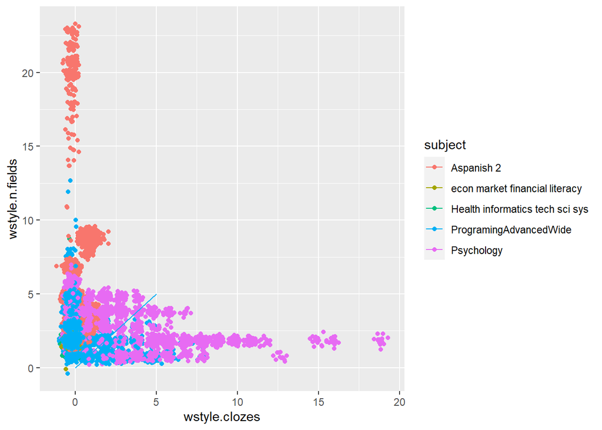

```r
crd %>%
  mutate(
    wstyle.clozes = rnorm(length(wstyle.clozes),-.2,.2) + wstyle.clozes,
    wstyle.n.fields = rnorm(length(wstyle.n.fields),-.2,.2) + wstyle.n.fields,
    wstyle.cards.per.note = rnorm(length(wstyle.cards.per.note),-.2,.2) + wstyle.cards.per.note
  ) %>%
ggplot(aes(wstyle.clozes,wstyle.n.fields,color=subject)) +
  geom_point() +
  geom_segment(aes(x = 0, y = 0, xend = 5, yend = 5))
```

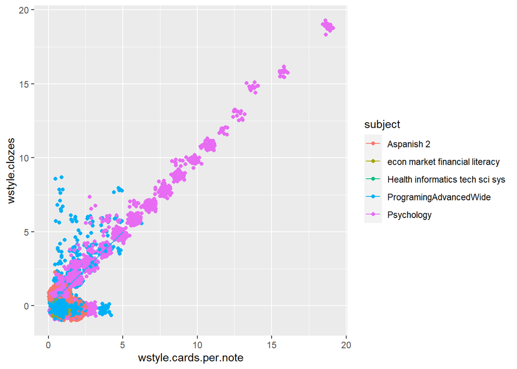

```r
crd %>%
  mutate(
    wstyle.clozes = rnorm(length(wstyle.clozes),-.2,.2) + wstyle.clozes,
    wstyle.n.fields = rnorm(length(wstyle.n.fields),-.2,.2) + wstyle.n.fields,
    wstyle.cards.per.note = rnorm(length(wstyle.cards.per.note),-.2,.2) + wstyle.cards.per.note
  ) %>%
ggplot(aes(wstyle.cards.per.note,wstyle.clozes,color=subject)) +
  geom_point() +
  geom_segment(aes(x = 0, y = 0, xend = 5, yend = 5))
```

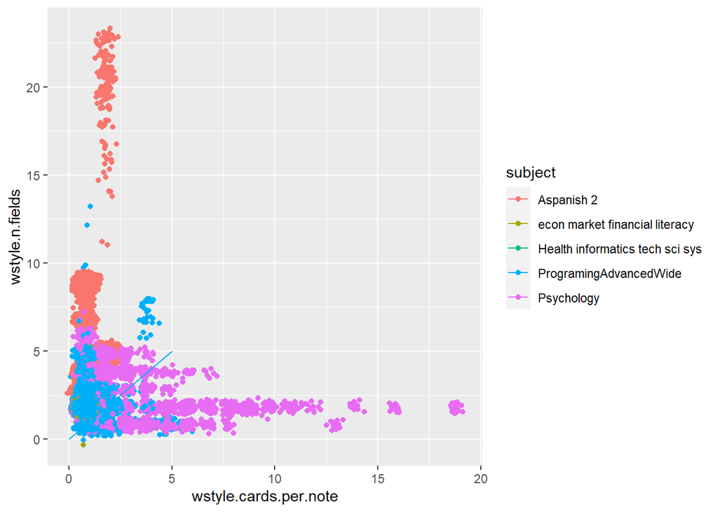

```r
crd %>%
  mutate(
    wstyle.clozes = rnorm(length(wstyle.clozes),-.2,.2) + wstyle.clozes,
    wstyle.n.fields = rnorm(length(wstyle.n.fields),-.2,.2) + wstyle.n.fields,
    wstyle.cards.per.note = rnorm(length(wstyle.cards.per.note),-.2,.2) + wstyle.cards.per.note
  ) %>%
ggplot(aes(wstyle.cards.per.note,wstyle.n.fields,color=subject)) +
  geom_point() +
  geom_segment(aes(x = 0, y = 0, xend = 5, yend = 5))
```

```r
# crd %>%
#   mutate(
#     wstyle.clozes = rnorm(length(wstyle.clozes),-.2,.2) + wstyle.clozes,
#     wstyle.n.fields = rnorm(length(wstyle.n.fields),-.2,.2) + wstyle.n.fields,
#     wstyle.cards.per.note = rnorm(length(wstyle.cards.per.note),-.2,.2) + wstyle.cards.per.note
#   ) %>%
# ggplot(aes(wstyle.clozes,wstyle.n.fields,color=wstyle.cards.per.note)) +
#   geom_point() +
#   scale_color_gradientn(colours=rainbow(5)) +
#   geom_segment(aes(x = 0, y = 0, xend = 5, yend = 5))
```

more cards per note than clozes and fields mostly because of unfinished cards then far more clozes and fields than cards made

```r
crd %>%
  filter(wstyle.clozes > 0 | wstyle.n.fields>2) %>%
  mutate(interest = (wstyle.clozes + wstyle.n.fields )/(wstyle.cards.per.note+1)) %>%
  filter(1 > interest) %>%
  select(card.txt,card.txt.old,wstyle.clozes,wstyle.cards.per.note,interest,wstyle.n.fields,dek.nam) %>%
  arrange(dek.nam) %>%
  filter(!duplicated(card.txt))
```

```
## # A tibble: 2 × 7
##   card.txt             card.txt.old wstyle.clozes wstyle.cards.per.note interest
##   <chr>                <chr>                <int>                 <int>    <dbl>
## 1 Answer TRUE or FALS… "<div><font…             4                     5    0.833
## 2 Theorem 2 A linear … "<div><font…             1                     2    0.667
## # ℹ 2 more variables: wstyle.n.fields <int>, dek.nam <chr>
```

```r
crd %>%
  #filter(wstyle.clozes>0) %>%
  mutate(interest = (wstyle.clozes + wstyle.n.fields )/wstyle.cards.per.note) %>%
  arrange(-interest) %>%
  slice_head(n=10) %>%
  select(card.txt,card.txt.old,wstyle.clozes,wstyle.n.fields,wstyle.cards.per.note,interest,dek.nam) %>%
  arrange(dek.nam)%>%
  filter(!duplicated(dek.nam))
```

```
## # A tibble: 2 × 7
##   card.txt      card.txt.old wstyle.clozes wstyle.n.fields wstyle.cards.per.note
##   <chr>         <chr>                <int>           <int>                 <int>
## 1 "364 -- (n.)… "364\u001f(…             0              23                     2
## 2 "p.p1 {margi… "\n\n\n\n\n…             0              13                     1
## # ℹ 2 more variables: interest <dbl>, dek.nam <chr>
```

Cards with both lots of clozes and fields. Possibly bug.

```r
crd %>%
  mutate(interest = (wstyle.clozes)*(wstyle.n.fields-1)) %>%
  arrange(-interest) %>%
  slice_head(n=100) %>%
  select(card.txt,card.txt.old,interest,dek.nam) %>%
  arrange(-interest) %>%
  filter(!duplicated(dek.nam))
```

```
## # A tibble: 3 × 4
##   card.txt                                         card.txt.old interest dek.nam
##   <chr>                                            <chr>           <dbl> <chr>
## 1 1:Einstellung is when your 2:initial thought, a… "<div>{{c1:…       21 ACwass…
## 2 1:Diogenes was a 2:4th c. BC (c.412-c.323 BC):c… "{{c1::Diog…       19 Alogic…
## 3 21110 -- 514300 -- Business is business. -- Los… "21110\u001…       16 Aspani…
```

#### specific parts

count characters that are not letters. print extremes

```r
crd$wstyle.not.letters.percent <- 1 - ( str_count(crd$card.txt, pattern = "[:letter:]{1}")) / crd$wstyle.nchar

crd %>%
  arrange(wstyle.not.letters.percent) %>%
  slice_head(n = 3) %>%
  select(card.txt,card.txt.old,wstyle.not.letters.percent,dek.nam) %>%
  arrange(dek.nam)
```

```
## # A tibble: 3 × 4
##   card.txt                           card.txt.old wstyle.not.letters.p…¹ dek.nam
##   <chr>                              <chr>                         <dbl> <chr>
## 1 especialmente totalmente probable… "especialme…                  0.112 AAA ea…
## 2 especially totally, completely pr… "especially…                  0.112 AAA ea…
## 3 Open Container Initiative -- gove… "Open Conta…                  0.124 Progra…
## # ℹ abbreviated name: ¹wstyle.not.letters.percent
```

```r
crd %>%
  arrange(-wstyle.not.letters.percent) %>%
  slice_head(n = 3) %>%
  select(card.txt,card.txt.old,wstyle.not.letters.percent,dek.nam) %>%
  arrange(dek.nam)
```

```
## # A tibble: 3 × 4
##   card.txt            card.txt.old            wstyle.not.letters.percent dek.nam
##   <chr>               <chr>                                        <dbl> <chr>
## 1 16^5 ? -- 1,048,576 "16^5 ?\u001f1,048,576"                          1 Progra…
## 2 16^1 ? -- 16        "16^1 ?\u001f16"                                 1 Progra…
## 3 16^2 ? -- 256       "16^2 ?\u001f256"                                1 Progra…
```

```r
#summary(crd$wstyle.not.letters.percent)
```

Where the maths?

```r
crd$wstyle.symbols.weird <- 0
weirds <- c("→","sqrt","[latex]","^","σ","µ","β","α","𝜃","η","π","∈","ℝ","√","∪","≠","∅","≥","≤","∞","ˣ","₁","₀","²","³","[$]")#,

for(i in weirds) {
crd$wstyle.symbols.weird <- crd$wstyle.symbols.weird + str_count(crd$card.txt.old,fixed(i))
}

crd %>%
  arrange(-wstyle.symbols.weird) %>%
  slice_head(n = 3) %>%
  select(card.txt,card.txt.old,wstyle.symbols.weird,dek.nam) %>%
  arrange(dek.nam)
```

```
## # A tibble: 3 × 4
##   card.txt                             card.txt.old wstyle.symbols.weird dek.nam
##   <chr>                                <chr>                       <dbl> <chr>
## 1 "Exponent Rules -- -- (X^b)(Y^b) = … "Exponent R…                   22 AB sta…
## 2 "Explain how a geometric series $\\… "[latex]Exp…                   21 MathAd…
## 3 "Prove the Power Rule for Different… "[latex]Pro…                   20 MathAd…
```

Count images

```r
crd$wstyle.images <- str_count(string = crd$card.txt.old,fixed('<img src='))

crd %>%
  arrange(-wstyle.images ) %>%
  slice_head(n = 3) %>%
  select(card.txt,card.txt.old,wstyle.images,dek.nam) %>%
  arrange(dek.nam)
```

```
## # A tibble: 3 × 4
##   card.txt                                    card.txt.old wstyle.images dek.nam
##   <chr>                                       <chr>                <int> <chr>
## 1 "What is the typical formula for the expec… "What is th…            14 AAtech…
## 2 "define studentized residual (regression) … "define stu…            12 AAtech…
## 3 "Multilevel Model:& ; Repeated Measures --… "Multilevel…             7 MathAd…
```

Count sounds

```r
crd$wstyle.sounds <- str_count(string = crd$card.txt.old,fixed('[sound:'))

crd %>%
  arrange(-wstyle.sounds ) %>%
  slice_head(n = 3) %>%
  select(card.txt,card.txt.old,wstyle.sounds,dek.nam) %>%
  arrange(dek.nam)
```

```
## # A tibble: 3 × 4
##   card.txt                                    card.txt.old wstyle.sounds dek.nam
##   <chr>                                       <chr>                <int> <chr>
## 1 What are the three steps of chunking? -- F… "What are t…             3 ACwass…
## 2 A query in a graph database is called a(n)… "A query in…             2 Progra…
## 3 ______ do not store relationships as perce… "______ do …             2 Progra…
```

Document (cards) Term (words) Matrix for counting words

```r
crd <- crd[order(crd$cid),]
require(textmineR, quietly = T)
dtm <- CreateDtm(doc_vec = crd$card.txt,
                 # character vector of documents
                 doc_names = crd$cid,
                 # document names, optional
                 ngram_window = c(1,1),
                 # minimum and maximum n-gram length
                 stopword_vec = c(),
                 # this is the default value
                 lower = TRUE, # lowercase - this is the default value
                 remove_punctuation = TRUE,
                 # punctuation - this is the default
                 remove_numbers = TRUE,
                 # numbers - this is the default
                 verbose = T, # Turn off status bar for this demo
                 cpus = 2)
dim(dtm)
```

```
## [1] 56832 61075
```

```r
# View(dtm[1:100,1:100])
# dtm[1:100, 1:100]@Dimnames[[1]]
# dtm[1:100, 1:100]@Dimnames[[2]]
# dtm[1:100, 1:100]@p
saveRDS(dtm,"DocTermMat.RDS")
```

Count common words

```r
wuf <- unlist(tidytext::stop_words[,1]  )
names(wuf) <- NULL
stopword_vec = unique(c(stopwords::stopwords("en"),
      stopwords::stopwords(language = "en",source = "smart"),
      stopwords::stopwords(language = "en", source = "marimo"),
    stopwords::stopwords(language = "en", source = "nltk"),
    wuf  ))

crd <- crd[order(crd$cid),]
woof <- dtm@Dimnames[[2]] %in% stopword_vec
str(woof)
```

```
##  logi [1:61075] FALSE FALSE FALSE FALSE FALSE FALSE ...
```

```r
howl <- matrix(woof,ncol = 1)
common_per_card <- dtm %*% howl
crd$wstyle.common.words <- as.vector(common_per_card)

crd %>%
  arrange((wstyle.common.words  ) ) %>%
  slice_head(n = 3) %>%
  select(card.txt,card.txt.old,dek.nam,wstyle.common.words,wstyle.nchar) %>%
  arrange(dek.nam)
```

```
## # A tibble: 3 × 5
##   card.txt                 card.txt.old dek.nam wstyle.common.words wstyle.nchar
##   <chr>                    <chr>        <chr>                 <dbl>        <int>
## 1 Rules 1-5 1. -- Rules 1… "<b>Rules 1… AAlear…                   0           39
## 2 Rules 11-15 11. -- Rule… "<b>Rules 1… AAlear…                   0           54
## 3 Rules 11-15 11. Combat … "<b>Rules 1… AAlear…                   0           99
```

```r
crd %>%
  arrange(-wstyle.common.words) %>%
  slice_head(n = 3) %>%
  select(card.txt,card.txt.old,dek.nam,wstyle.common.words,wstyle.nchar) %>%
  arrange(dek.nam)
```

```
## # A tibble: 3 × 5
##   card.txt                 card.txt.old dek.nam wstyle.common.words wstyle.nchar
##   <chr>                    <chr>        <chr>                 <dbl>        <int>
## 1 "Design a system that s… "<h1 style=… Progra…                 970        14308
## 2 "Design Mint.com -- Not… "<h1 style=… Progra…                 892        14905
## 3 "Design a web crawler -… "<h1 style=… Progra…                 805        11964
```

count core vocab defined as new vocab in step 2 .. but why? what constitutes a core word is too fickle. it depends on how user chooses to divide his cards among decks. also 2grams are not doing anything here

```r
vocabulary.new <- readRDS(file = paste0(getwd(),"/new_vocabulary.RDS"))
#vocabulary.new[[2]][[1]]

itrs <- length(vocabulary.new[[2]])
crd <- crd[order(crd$cid),]
crd$wstyle.core.words <- 0
for(i in 1:itrs) { #i<-1
core_vocab <- vocabulary.new[[2]][[i]]
core_vocab <- str_replace_all(core_vocab,"_"," ")
core_vocab  <- setdiff(core_vocab,stopword_vec)
woof <- dtm@Dimnames[[2]] %in% core_vocab
howl <- matrix(woof,ncol = 1)
core_per_card <- as.vector(dtm %*% howl)
core_per_card <- (crd$subject == vocabulary.new[[1]][i]) * core_per_card
crd$wstyle.core.words[crd$wstyle.core.words == 0] <- core_per_card[crd$wstyle.core.words == 0]
}

crd %>%
  arrange((-wstyle.nchar + (wstyle.core.words * 1000) ) ) %>%
  slice_head(n = 3) %>%
  select(card.txt,card.txt.old,dek.nam,wstyle.core.words,wstyle.nchar) %>%
  arrange(dek.nam)
```

```
## # A tibble: 3 × 5
##   card.txt                   card.txt.old dek.nam wstyle.core.words wstyle.nchar
##   <chr>                      <chr>        <chr>               <dbl>        <int>
## 1 "Advantages of expert sys… "Advantages… AAtech…                 0         1176
## 2 "fake justification -- \"… "fake justi… ZTrash…                 0         1152
## 3 "5. Which of the followin… "5.  Which … econ m…                 0         1286
```

```r
crd %>%
  arrange(-wstyle.core.words/wstyle.nchar) %>%
  slice_head(n = 5) %>%
  select(card.txt,card.txt.old,dek.nam,wstyle.core.words,wstyle.nchar) %>%
  arrange(dek.nam)
```

```
## # A tibble: 5 × 5
##   card.txt                   card.txt.old dek.nam wstyle.core.words wstyle.nchar
##   <chr>                      <chr>        <chr>               <dbl>        <int>
## 1 Exit the shell -- exit     "Exit the s… Progra…                 3           22
## 2 Exit shell -- exit         "Exit shell… Progra…                 3           18
## 3 Initialize git repo -- gi… "Initialize… basic …                 5           31
## 4 Abort a rebase -- git reb… "Abort a re… basic …                 5           36
## 5 Abort a rebase -- git reb… "Abort a re… basic …                 5           36
```

```r
crd %>%
  arrange(-(wstyle.core.words )) %>%
  slice_head(n = 3) %>%
  select(card.txt,card.txt.old,dek.nam,wstyle.core.words,wstyle.nchar) %>%
  arrange(dek.nam)
```

```
## # A tibble: 3 × 5
##   card.txt                   card.txt.old dek.nam wstyle.core.words wstyle.nchar
##   <chr>                      <chr>        <chr>               <dbl>        <int>
## 1 "p.p1 {margin: 0.0px 0.0p… "\n<style t… Progra…               253         6497
## 2 "p.p1 {margin: 0.0px 0.0p… "\n\n\n\n\n… Progra…               246        11334
## 3 "Design the data structur… "<h1 style=… Progra…               268        10546
```

```r
if(F){
require(ggraptR)
require(GGally)
viz <- crd %>%
  select(contains('wstyle'),"subject")

crd %>%
  select(contains('wstyle')) %>%
  pairs()

ggpairs(viz)

ggraptR(viz)

?select()
}
```

## quanteda text statistics like readability

## card type constructs and deck purity

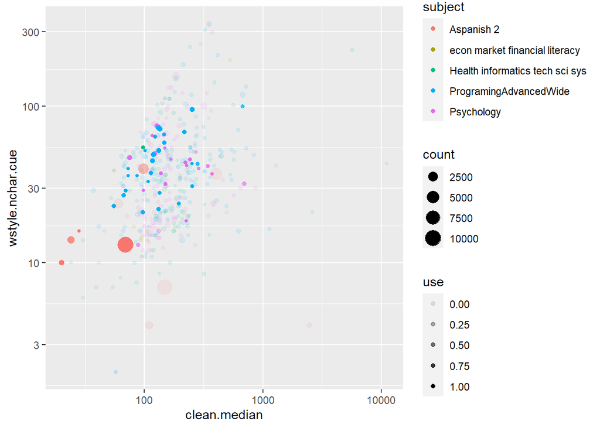

```r
crd %>%
  group_by(dek.nam) %>%
  summarize(subject=first(subject),
            dirty.median=median(wstyle.nchar.dirty),
            clean.median= median(wstyle.nchar),
            use=mean(reps>0),
            #wstyle.not.letters.percent=median(wstyle.not.letters.percent),
            wstyle.nchar.cue=median(wstyle.nchar.cue),
            count=n(),#orientation=lm(wstyle.nchar~wstyle.nchar.dirty)$coefficients[2]
            ) %>%
ggplot(aes(clean.median,wstyle.nchar.cue,color=subject,alpha=use,size=count)) + geom_point()+
  scale_x_log10()+scale_y_log10()#+ lims(x= c(0, 1000), y = c(0, 1000))
```

```r
if(F){
cloze_min <- str_extract_all('Changing a habit requires:\n<ol>\n<li>identifying a {{c1::cue}},</li>\n<li>having a {{c2::plan}}',pattern='\\{\\{c.+?\\}\\}') %>%
  lapply( FUN= function(x){
                  ut<-nchar(x)
                  max(min(ut[ut>1]),0)}) %>%
  unlist()
crd$card.txt.old[1:1000]


summary(cloze_min)
str_detect(crd$card.txt.old,fixed('{{c') )

str_split('Changing a habit -- requires:\n<ol>\n<li>identifying a {{c1::cue}},</li>\n<li>having a {{c2::plan}}',fixed("--")) %>%
  print() %>%
  unlist( ) %>%
  str_split(fixed("{{c")) %>%
  print() %>%
  unlist( ) %>%
   str_split(fixed("::")) %>%
  print() %>%
  unlist( ) %>%
  str_split(fixed("}}")) %>%
  unlist() %>%
  print()
}
```